# ActivityMonitoring

Sudheer Patil

June 28, 2019

# Reproducible Research - Activity Monitoring Project

Assignment written in R Markdown file

## Loading the data.

Steps involved are  
* Connect to the URL and download the zipped file.  
* Unzip the csv file and read the file into memory

```r
url1 <- "https://d396qusza40orc.cloudfront.net/repdata%2Fdata%2Factivity.zip"

temp <- tempfile()
download.file(url1, temp)
p1 <- unz(temp, "activity.csv")

act <- read.table(p1, header = TRUE, sep = ",", stringsAsFactors = FALSE )
```

## What is mean total number of steps taken per day?

- Ignore the missing values in the dataset.
- Calculate the total number of steps taken per day.
- Make a histogram of the total number of steps taken each day.
- Calculate and report the mean and median of the total number of steps taken per day

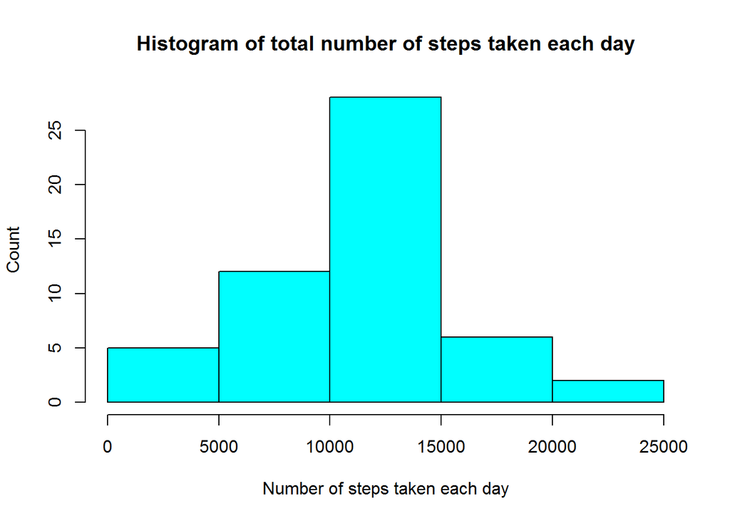

```r
suppressWarnings(library(data.table))
act1 <- setDT(na.omit(act))
act1 <- act1[ , .(Sum.steps = sum(steps),
                  Mean.steps = mean(steps),
                  Median.steps = median(steps)), by = date ]

hist(act1$Sum.steps,
     xlab="Number of steps taken each day",
     ylab="Count",
     main="Histogram of total number of steps taken each day",
     col= 5)
```

```r
Mean_steps <- mean(act1$Sum.steps)
Median_steps <- median(act1$Sum.steps)
print(paste("Mean number of steps", Mean_steps))
```

```
## [1] "Mean number of steps 10766.1886792453"
```

```r
print(paste("Median number of steps", Median_steps))
```

```
## [1] "Median number of steps 10765"
```

## What is the average daily activity pattern?

- Make a time series plot (i.e. type=“l”) of the 5-minute interval (x-axis) and the average number of steps taken, averaged across all days (y-axis)
- Which 5-minute interval, on average across all the days in the dataset, contains the maximum number of steps?

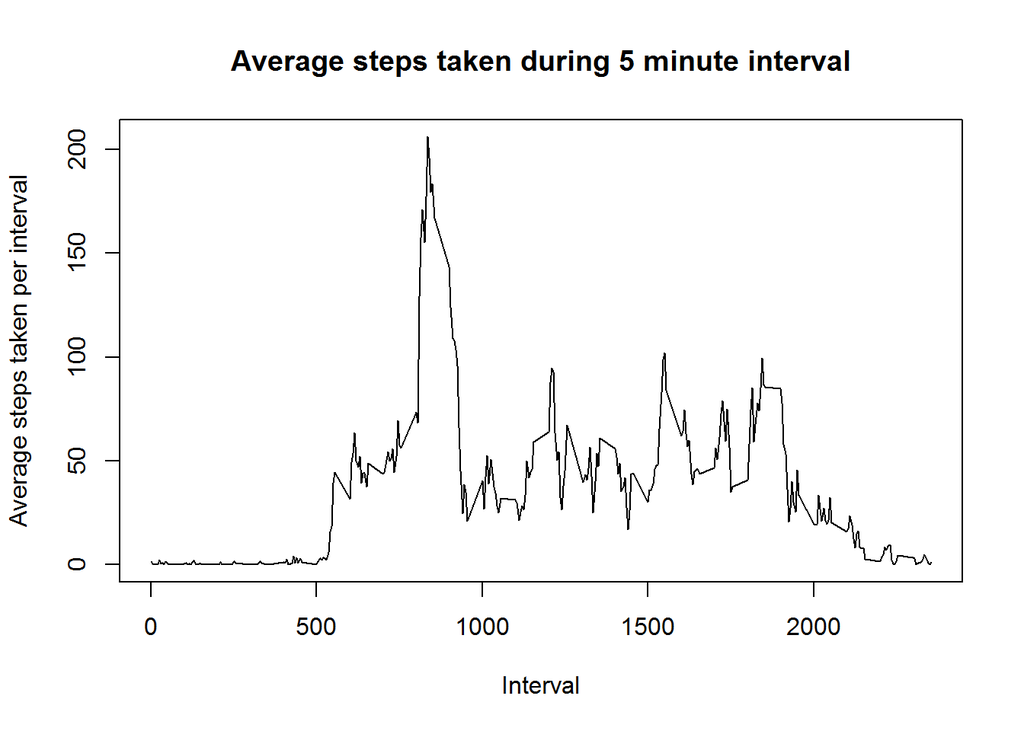

```r
act2 <- setDT(na.omit(act))
act2 <- act2[ , .(Avg_stepsperinter = mean(steps)), by = interval ]
with (act2, plot(interval, Avg_stepsperinter,
                 type="l",
                 xlab="Interval",
                 ylab="Average steps taken per interval",
                 main="Average steps taken during 5 minute interval"))
```

```r
max_steps_interval <- act2$interval[which.max(act2$Avg_stepsperinter)]
print(paste("On Average max steps occur in interval", max_steps_interval ))
```

```
## [1] "On Average max steps occur in interval 835"
```

## Imputing missing values

- Calculate and report the total number of missing values in the dataset (i.e. the total number of rows with NAs)
- Filling in all of the missing values in the dataset with values of the mean of the steps of that interval. and creat a new data set with imputed values. This is act.
- Make a histogram of the total number of steps taken each day and Calculate and report the mean and median total number of steps taken per day.

Since the mean values are imputed to the NA values, the mean of the steps did not change. However the median and mean values are the same.

```r
num_NA <- sum(is.na(act$steps))
print(paste("Total number of missing values in steps column", num_NA ))
```

```
## [1] "Total number of missing values in steps column 2304"
```

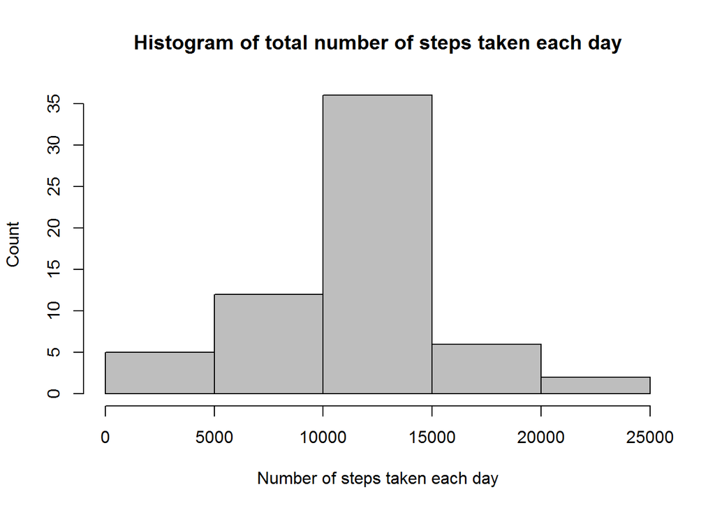

```r
for( i in 1:nrow(act)){
    if(is.na(act$steps[i])){
        act$steps[i] <- act2$Avg_stepsperinter[which(act2$interval == act$interval[i])]
    }
}
act3 <- setDT(act)
act3 <- act3[ , .(Sum.steps = sum(steps),
                  Mean.steps = mean(steps),
                  Median.steps = median(steps)), by = date ]
hist(act3$Sum.steps,
     xlab="Number of steps taken each day",
     ylab="Count",
     main="Histogram of total number of steps taken each day",
     col= 8)
```

```r
Mean_steps <- mean(act3$Sum.steps)
Median_steps <- median(act3$Sum.steps)
print(paste("Mean number of steps", Mean_steps))
```

```
## [1] "Mean number of steps 10766.1886792453"
```

```r
print(paste("Median number of steps", Median_steps))
```

```
## [1] "Median number of steps 10766.1886792453"
```

## Are there differences in activity patterns between weekdays and weekends?

For this part the weekdays() function may be of some help here. Use the dataset with the filled-in missing values for this part.

Create a new factor variable in the dataset with two levels – “weekday” and “weekend” indicating whether a given date is a weekday or weekend day. Make a panel plot containing a time series plot (i.e. type=“l”) of the 5-minute interval (x-axis) and the average number of steps taken, averaged across all weekday days or weekend days (y-axis). See the README file in the GitHub repository to see an example of what this plot should look like using simulated data.

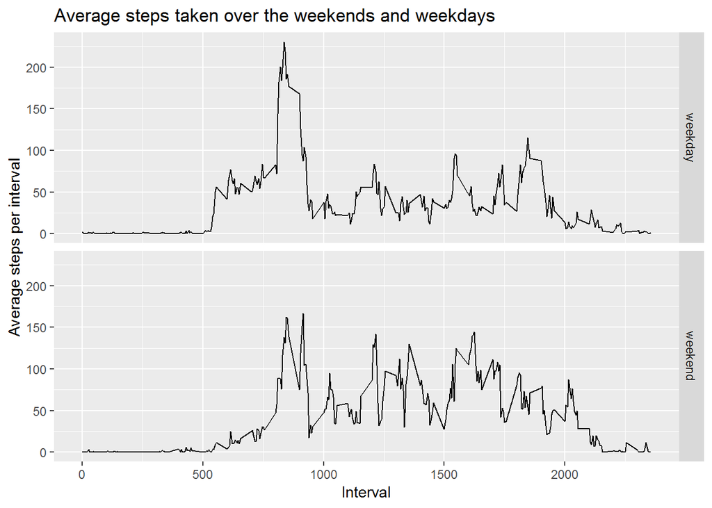

```r
act$date <- as.POSIXct(act$date, format = "%Y-%m-%d" )
act[ , 'days'] <- weekdays(act$date)
act[ ,'typeofday'] <- "weekday"
act$typeofday[act$days %in% c("Saturday", "Sunday")] <- "weekend"
act$typeofday <- as.factor(act$typeofday)
suppressMessages(library(ggplot2))
act4 <- setDT(act)
act4 <- act4[ , .(Avg_stepsperinter = mean(steps)), by = c('interval', 'typeofday') ]
qplot(interval, Avg_stepsperinter, data = act4, geom = "line",
      facets = typeofday ~. , xlab = "Interval", ylab = "Average steps per interval",
      main = "Average steps taken over the weekends and weekdays")
```